# 5th Protocol: Precipitation

Cheyenne Rueda and Simone Massaro

31 mayo 2021

## Analysis

```r
prec <- read_csv("../Data_lectures/5_Precipitation/P_4sites.csv")
et <- read_csv("../Data_lectures/5_Precipitation/ET_4sites.csv")
sites <- read_csv("station_data.csv") %>%
  rename(site=`Site-abb`, full_name = Site)
```

```r
prec_avg <- prec %>%
  select(-Date) %>%
  gather("site", "prec") %>%
    group_by(site) %>%
  summarise(prec=mean(prec))

et_avg <- et %>%
  select(-Date) %>%
  gather("site", "et") %>%
    group_by(site) %>%
  summarise(et=mean(et))

sites_avg <- sites %>%
  inner_join(et_avg, by="site") %>%
  inner_join(prec_avg, by="site")
```

## ET and precipitation at different latitudes

*Visualise the annual sums of evapotranspiration and precipitation according to its geographic latitude (boxplot?). How and why does precipitation and evapotranspiration varies? Which impact has the underlying ecosystem?*

```r
# this t makes no sense as name TODO chanve this
prec_t <- prec %>%
  gather("site", "prec", -Date)

et_t <- et %>%
  gather("site", "et", -Date)

prec_et <- left_join(prec_t, et_t, by=c("Date", "site"))

sites <- sites %>%
  inner_join(prec_et, by="site")
```

```r
sites
```

| site | full_name | Lat | Long | Height | Veg_type | Mean_airT | Mean_precipitation | Date | prec | et |
| --- | --- | --- | --- | --- | --- | --- | --- | --- | --- | --- |
| DE_Hai | Hainich | 51.0792 | 10.4522 | 430 | DBF | 8.3 | 720 | 2004-01-01 | 763.000 | 390.0650 |
| DE_Hai | Hainich | 51.0792 | 10.4522 | 430 | DBF | 8.3 | 720 | 2005-01-01 | 736.000 | 445.5210 |
| DE_Hai | Hainich | 51.0792 | 10.4522 | 430 | DBF | 8.3 | 720 | 2006-01-01 | 660.400 | 432.0623 |
| DE_Hai | Hainich | 51.0792 | 10.4522 | 430 | DBF | 8.3 | 720 | 2007-01-01 | 1046.900 | 446.2708 |
| DE_Hai | Hainich | 51.0792 | 10.4522 | 430 | DBF | 8.3 | 720 | 2008-01-01 | 612.300 | 406.9348 |
| DE_Hai | Hainich | 51.0792 | 10.4522 | 430 | DBF | 8.3 | 720 | 2009-01-01 | 923.581 | 435.0945 |
| FI_Hyy | Hyytiala | 61.8474 | 24.2948 | 181 | ENF | 3.8 | 709 | 2004-01-01 | 513.659 | 273.4945 |
| FI_Hyy | Hyytiala | 61.8474 | 24.2948 | 181 | ENF | 3.8 | 709 | 2005-01-01 | 667.971 | 268.1941 |
| FI_Hyy | Hyytiala | 61.8474 | 24.2948 | 181 | ENF | 3.8 | 709 | 2006-01-01 | 504.483 | 281.0700 |
| FI_Hyy | Hyytiala | 61.8474 | 24.2948 | 181 | ENF | 3.8 | 709 | 2007-01-01 | 537.789 | 345.1042 |

[output cut: 14 more lines]

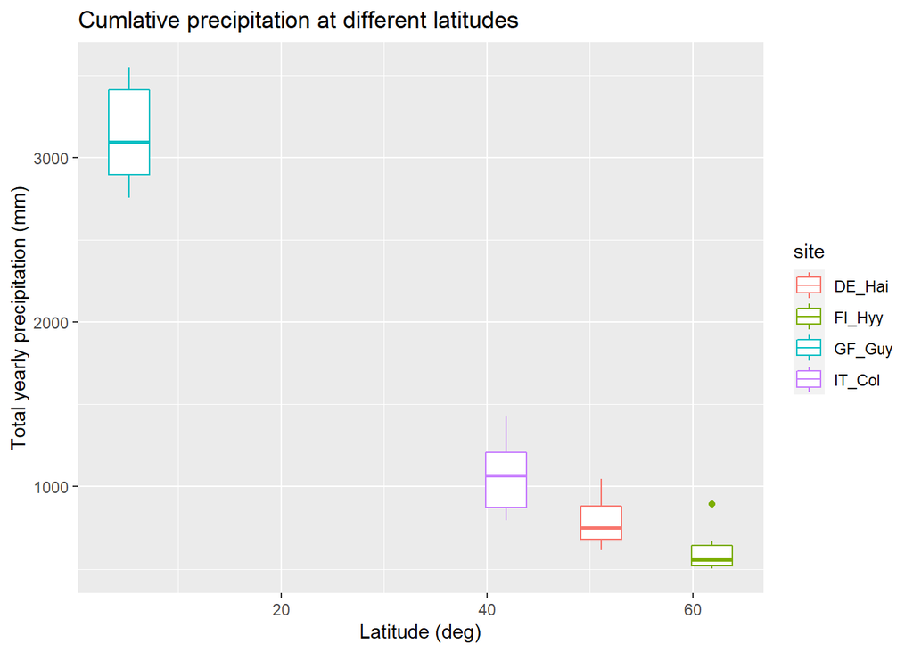

```r
(prec_box <-  ggplot(sites, aes(Lat, prec, colour=site)) +
  geom_boxplot() +
   labs(title="Cumlative precipitation at different latitudes",
        y="Total yearly precipitation (mm)",
        x="Latitude (deg)"))
```

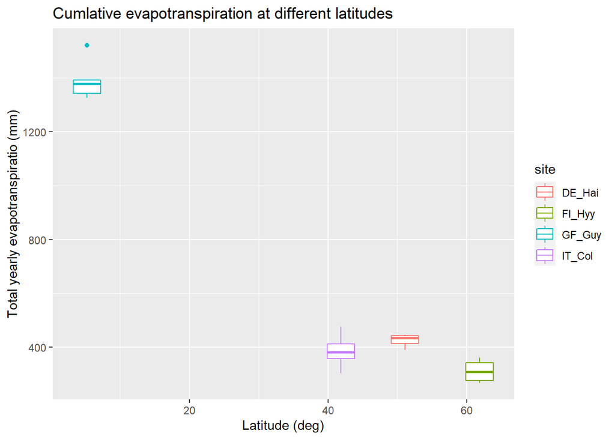

```r
(et_box <- ggplot(sites, aes(Lat, et, colour=site)) +
  geom_boxplot() +
    labs(title="Cumlative evapotranspiration at different latitudes",
        y="Total yearly evapotranspiratio (mm)",
        x="Latitude (deg)"))
```

## Evapotranspiration index

*Precipitation is used as a driver/source for evapotranspiration. The ratio between evapotranspiration and precipitation (evapotranspiration index = ET_idx) is a very useful indicator how precipitation is used by plants during photosynthesis. Calculate the ET_idx for all sites and visualise it. What surprised you and how do the ET_idx differs across ecosystems? Discuss.*

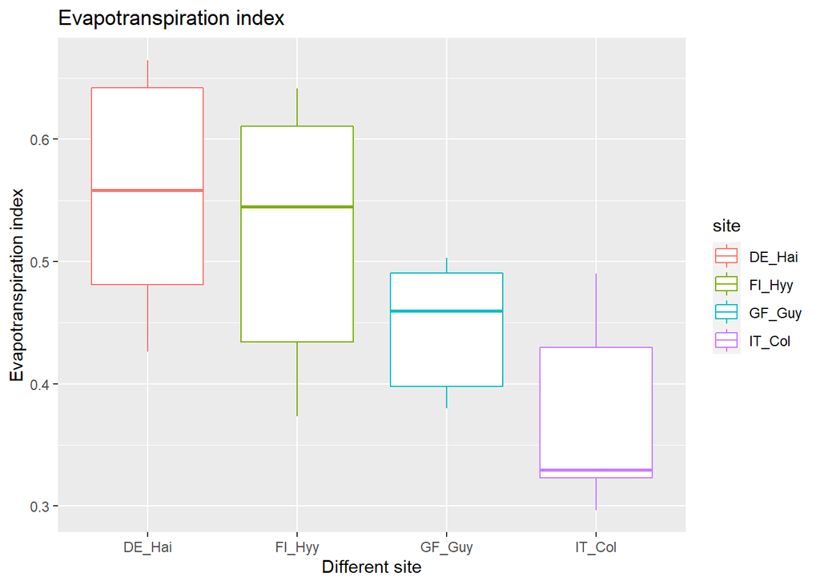

```r
sites$et_idx <- sites$et/sites$prec

ggplot(sites,
       aes(site, et_idx, colour = site))+
         geom_boxplot()+
         labs(title="Evapotranspiration index", x="Different site", y="Evapotranspiration index")
```

As we can see,evapotranspiration index is the fraction between what is intercepted by cannopy and what is being lose by soil hydrology processes. Other variables such as wind speed, surface humidity and solar radiation are not being taken into account in the calculation of this index, which probably are the ones causing differences on what it could have been expected at the beginning for some of the places.